# Risk Factor Analysis

## Outcome Variable

**Outcome Variable:** whz

## Predictor Variables

**Intervention Variable:** exclfeed36

**Adjustment Set:**

- arm
- sex
- brthmon
- W_mage
- meducyrs
- feducyrs
- hhwealth_quart
- hfoodsec
- W_mhtcm
- W_mwtkg
- W_mbmi
- vagbrth
- W_gagebrth
- W_birthwt
- W_birthlen
- W_nrooms
- W_nchldlt5
- month
- W_parity
- impfloor
- impsan
- safeh20
- delta_W_mage
- delta_meducyrs
- delta_feducyrs
- delta_hhwealth_quart
- delta_hfoodsec
- delta_W_mhtcm
- delta_W_mwtkg
- delta_W_mbmi
- delta_vagbrth
- delta_W_gagebrth
- delta_W_birthwt
- delta_W_birthlen
- delta_W_nrooms
- delta_W_nchldlt5
- delta_month
- delta_W_parity
- delta_impfloor
- delta_impsan
- delta_safeh20

## Stratifying Variables

The analysis was stratified on these variable(s):

- agecat

## Data Summary

| agecat | exclfeed36 | n_cell | n | outcome_variable |
| --- | --- | --- | --- | --- |
| Birth | 1 | 9348 | 13693 | whz |
| Birth | 0 | 4345 | 13693 | whz |
| 6 months | 1 | 11001 | 17787 | whz |
| 6 months | 0 | 6786 | 17787 | whz |
| 24 months | 1 | 7470 | 12450 | whz |
| 24 months | 0 | 4980 | 12450 | whz |

The following strata were considered:

- agecat: 24 months
- agecat: 6 months
- agecat: Birth

## Methods Detail

We’re interested in the causal parameters $E[Y_a]$ for all values of $a \in \mathcal{A}$. These parameters represent the mean outcome if, possibly contrary to fact, we intervened to set all units to have $A=a$. Under the randomization and positivity assumptions, these are identified by the statistical parameters $\psi_a=E_W[E_{Y|A,W}(Y|A=a,W)]$. In addition, we’re interested in the mean of $Y$, $E[Y]$ under no intervention (the observed mean). We will estimate these parameters by using SuperLearner to fit the relevant likelihood factors – $E_{Y|A,W}(Y|A=a,W)$ and $p(A=a|W)$, and then updating our likelihood fit using a joint TMLE.

For unadjusted analyses ($W=\{\}$), initial likelihoods were estimated using Lrnr_glm to estimate the simple $E(Y|A)$ and Lrnr_mean to estimate $p(A)$. For adjusted analyses, a small library containing Lrnr_glmnet, Lrnr_xgboost, and Lrnr_mean was used.

Having estimated these parameters, we will then use the delta method to estimate relative risks and attributable risks relative to a prespecified baseline level of $A$.

# Results Detail

## Results Plots

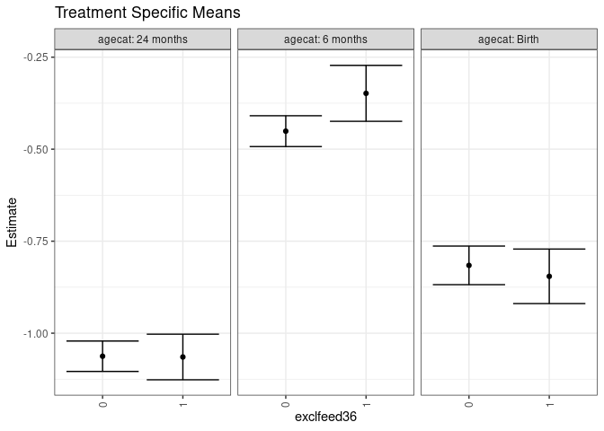

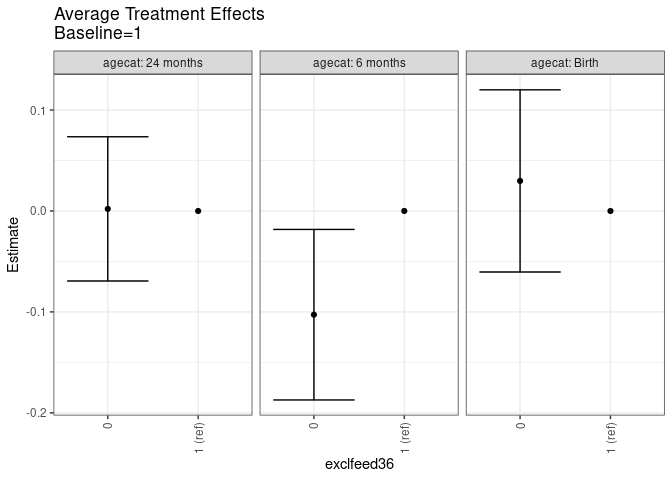

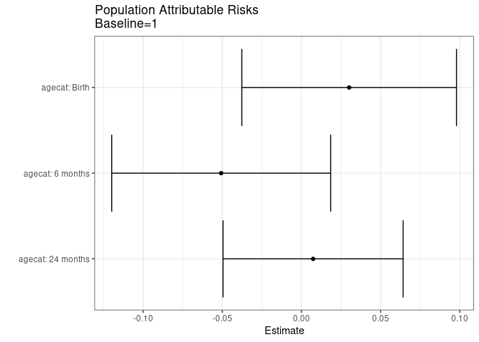

## Results Table

### Parameter: TSM

| agecat | intervention_level | baseline_level | estimate | ci_lower | ci_upper |
| --- | --- | --- | --- | --- | --- |
| Birth | 1 | NA | -0.8455438 | -0.9196309 | -0.7714566 |
| Birth | 0 | NA | -0.8157610 | -0.8682209 | -0.7633011 |
| 6 months | 1 | NA | -0.3483352 | -0.4243445 | -0.2723260 |
| 6 months | 0 | NA | -0.4510791 | -0.4929891 | -0.4091692 |
| 24 months | 1 | NA | -1.0646924 | -1.1266261 | -1.0027588 |
| 24 months | 0 | NA | -1.0626227 | -1.1039478 | -1.0212977 |

### Parameter: E(Y)

| agecat | intervention_level | baseline_level | estimate | ci_lower | ci_upper |
| --- | --- | --- | --- | --- | --- |
| Birth | NA | NA | -0.8153652 | -0.8567843 | -0.773946 |
| 6 months | NA | NA | -0.3990287 | -0.4345594 | -0.363498 |
| 24 months | NA | NA | -1.0573220 | -1.0920773 | -1.022567 |

### Parameter: ATE

| agecat | intervention_level | baseline_level | estimate | ci_lower | ci_upper |
| --- | --- | --- | --- | --- | --- |
| Birth | 1 | 1 | 0.0000000 | 0.0000000 | 0.000000 |
| Birth | 0 | 1 | 0.0297828 | -0.0604555 | 0.120021 |
| 6 months | 1 | 1 | 0.0000000 | 0.0000000 | 0.000000 |
| 6 months | 0 | 1 | -0.1027439 | -0.1872178 | -0.018270 |
| 24 months | 1 | 1 | 0.0000000 | 0.0000000 | 0.000000 |
| 24 months | 0 | 1 | 0.0020697 | -0.0693656 | 0.073505 |

### Parameter: PAR

| agecat | intervention_level | baseline_level | estimate | ci_lower | ci_upper |
| --- | --- | --- | --- | --- | --- |
| Birth | 1 | NA | 0.0301786 | -0.0376393 | 0.0979965 |
| 6 months | 1 | NA | -0.0506935 | -0.1198384 | 0.0184515 |
| 24 months | 1 | NA | 0.0073705 | -0.0495083 | 0.0642492 |